# Week 3 - Data analysis workflow

Fall 2021

[figure not shown]

## Exporatory data analysis

1. Think about your problem. **What is the question**, how will it be answered?
2. **Model fitting**

## Model building - continuous variables

- How is the data generated?
- Generative statistical model  
  Example: yield response to density: quadratic function.

## Continuous variable

```r
quadratic <- function(x, a, b, c){
  mu <- (a + b*x + c*x^2)
  epsilon <- rnorm(length(x),0,.1)
  y <- mu + epsilon
  return(y)
}
x <- seq(0,14, length.out = 100)
y <- quadratic(x, 4,.5,-.026)

my_data <- data.frame(x,y)
```

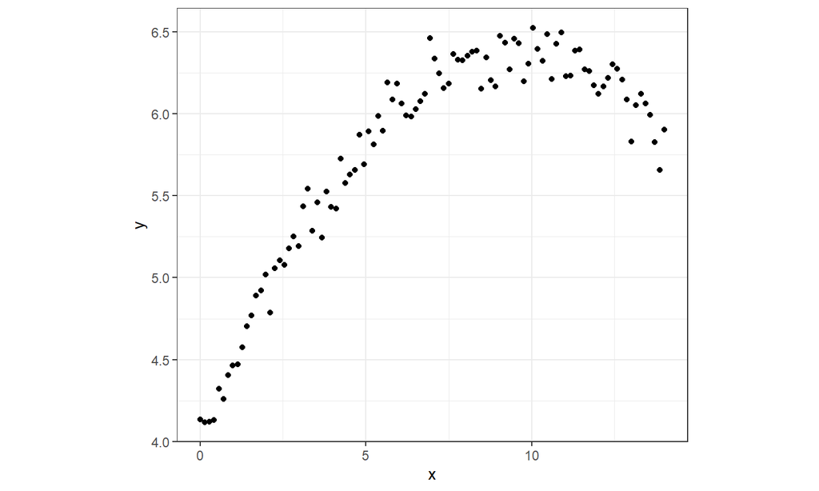

```r
my_data %>%
  ggplot(aes(x,y))+
  geom_point()+
  theme_bw()+
  theme(aspect.ratio = .85)
```

Do linear regression on that:

```r
my_lm1 <- lm(y~x, data = my_data)
my_lm2 <- lm(y~x+I(x^2), data = my_data)

Anova(my_lm1, my_lm2)
```

```
## Anova Table (Type II tests)
##
## Response: y
##            Sum Sq Df F value    Pr(>F)
## x         29.1204  1  2531.5 < 2.2e-16 ***
## Residuals  1.1158 97
## ---
## Signif. codes:  0 '***' 0.001 '**' 0.01 '*' 0.05 '.' 0.1 ' ' 1
```

## Categorical variables

```r
usda <- read.csv("../data/USDAsurvey_00-18.csv")

usda_linear1 <- lm(Value ~ State, data = usda)

usda_linear1
```

```
##
## Call:
## lm(formula = Value ~ State, data = usda)
##
## Coefficients:
##         (Intercept)        StateCOLORADO        StateDELAWARE
##            152.2138             -26.0518              -9.1612
##        StateGEORGIA        StateILLINOIS         StateINDIANA
##            -22.0035               7.7185               1.2419
##           StateIOWA          StateKANSAS        StateMARYLAND
##             15.5014             -33.7607             -22.3685
##       StateMICHIGAN       StateMINNESOTA     StateMISSISSIPPI
##            -24.5368              -0.8273             -25.1823
##       StateMISSOURI        StateNEBRASKA  StateNORTH CAROLINA
##            -25.6160               3.3559             -47.1941
##   StateNORTH DAKOTA            StateOHIO    StatePENNSYLVANIA
##            -51.7377              -7.4608             -32.3332
## StateSOUTH CAROLINA    StateSOUTH DAKOTA       StateTENNESSEE
##            -60.3330             -41.1429             -27.3934
##          StateTEXAS       StateWISCONSIN
##            -47.6219             -14.0488
```

## 3. ANOVA

**!!** What is the difference between `Anova()` and `anova()`?

```r
anova(usda_linear1) # default in R
```

```
## Analysis of Variance Table
##
## Response: Value
##              Df   Sum Sq Mean Sq F value    Pr(>F)
## State        22 12031901  546905  477.68 < 2.2e-16 ***
## Residuals 27819 31850787    1145
## ---
## Signif. codes:  0 '***' 0.001 '**' 0.01 '*' 0.05 '.' 0.1 ' ' 1
```

```r
Anova(usda_linear1, type = 3) # car package
```

```
## Anova Table (Type III tests)
##
## Response: Value
##               Sum Sq    Df  F value    Pr(>F)
## (Intercept) 13947760     1 12182.20 < 2.2e-16 ***
## State       12031901    22   477.68 < 2.2e-16 ***
## Residuals   31850787 27819
## ---
## Signif. codes:  0 '***' 0.001 '**' 0.01 '*' 0.05 '.' 0.1 ' ' 1
```

```r
usda_linear1_aug <- augment(usda_linear1)
usda_linear1_aug$.std.resid <- resid(usda_linear1, type="pearson", scaled=T)
```

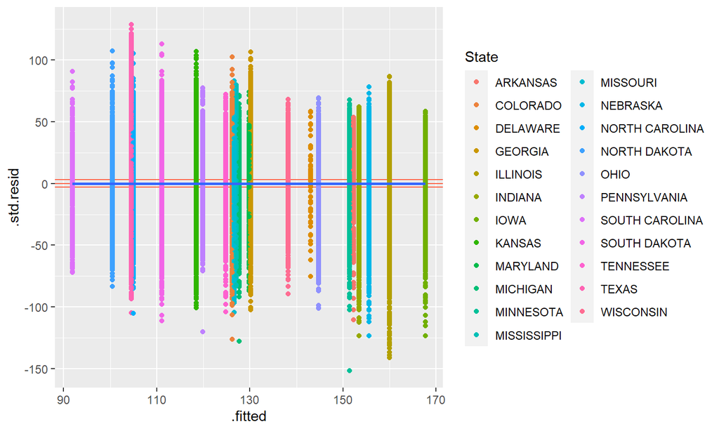

```r
usda_linear1_aug %>%
  ggplot(aes(x=.fitted, y=.std.resid))+
  geom_hline(yintercept = c(-3,0,3), color="tomato")+
  geom_point(aes(color=State))+
  geom_smooth()
```

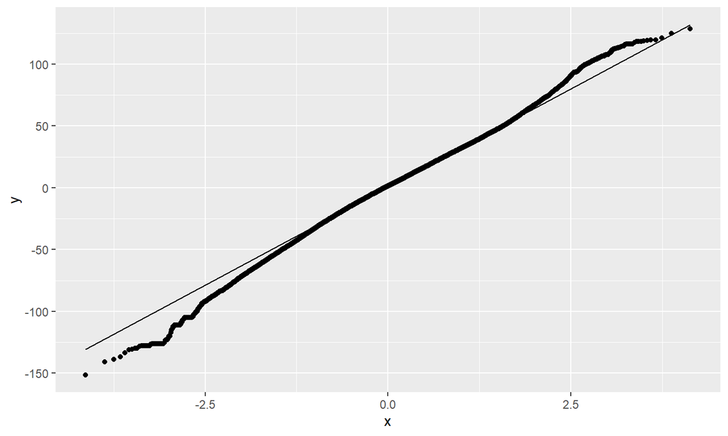

```r
usda_linear1_aug %>%
  ggplot(aes(sample=.std.resid))+
  stat_qq()+
  stat_qq_line()
```

```r
usda_linear1_means <- emmeans(usda_linear1, specs = ~ State)

usda_linear1_cld <- cld(usda_linear1_means,
                       adjust = "none",
                       Letters = letters,
                       reversed = TRUE,
                       comparisons = TRUE)
```

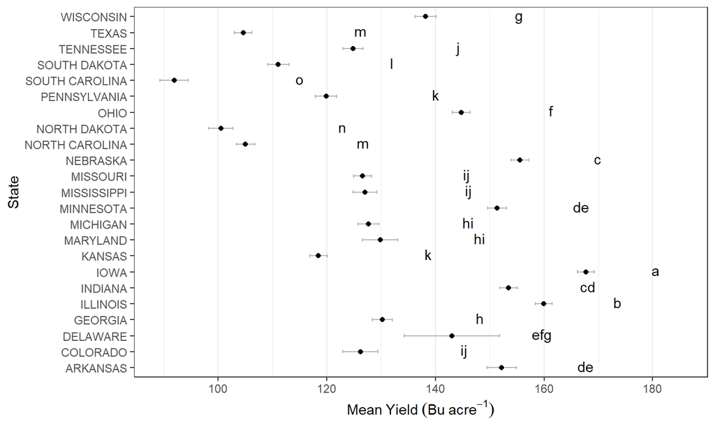

```r
usda_linear1_cld <- usda_linear1_cld %>% as.data.frame()

usda_linear1_cld %>%
  ggplot(aes(emmean, State))+
  geom_errorbarh(aes(xmin = lower.CL, xmax = upper.CL), color = "grey70", height = .2)+
  geom_point()+
  geom_text(aes(label = .group, x = emmean + nchar(.group)*1.1), nudge_y = 0.1)+
  labs(x = expression(Mean~Yield~(Bu~acre^{-1})))+
  theme_bw()+
  theme(panel.grid.major.y = element_blank(),
        panel.grid.minor.y = element_blank())
```

```r
# Remove the spaces from the character
usda_linear1_cld$.group <- gsub(" ", "", usda_linear1_cld$.group, fixed = TRUE)

# Create a column "order" with the order of the State factor
usda_linear1_cld <- usda_linear1_cld %>%
  arrange(emmean) %>%
  rownames_to_column("order") %>%
  mutate(order = as.numeric(order))

# Reorder the states depending on their means
usda_linear1_cld <- usda_linear1_cld %>%
  mutate(State = factor(State, levels = usda_linear1_cld$State[usda_linear1_cld$order]))
```

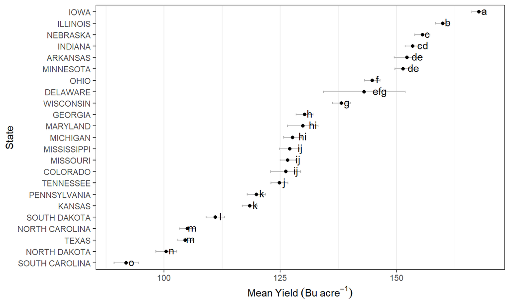

```r
usda_linear1_cld %>%
  ggplot(aes(emmean, State))+
  geom_errorbarh(aes(xmin = lower.CL, xmax = upper.CL), color = "grey70", height = .2)+
  geom_point()+
  geom_text(aes(label = .group, x = emmean + nchar(.group)*1.1), nudge_y = 0.1)+
  labs(x = expression(Mean~Yield~(Bu~acre^{-1})))+
  theme_bw()+
  theme(panel.grid.major.y = element_blank(),
        panel.grid.minor.y = element_blank()) -> usda_linear1_ggplot; usda_linear1_ggplot
```

## Other possible models

```r
class(usda$Year)
```

```
## [1] "integer"
```

```r
usda <- usda %>% mutate(fYear = as.factor(Year))

usda_linear2 <- lm(Value ~ State + Year, data = usda)

usda_linear3 <- lm(Value ~ State + fYear, data = usda)

usda_linear4 <- lm(Value ~ State * Year, data = usda)

usda_linear5 <- lm(Value ~ State * fYear, data = usda)
```

## 4. Model selection

**AIC**

```r
AICtable(AIC(usda_linear1,
             usda_linear2,
             usda_linear3,
             usda_linear4,
             usda_linear5))
```

```
##               df      AIC     Delta ModelLik ModelWt
## usda_linear5 438 263602.2     0.000        1       1
## usda_linear3  42 268737.9  5135.687        0       0
## usda_linear4  47 270846.8  7244.629        0       0
## usda_linear2  25 271373.8  7771.679        0       0
## usda_linear1  24 275131.1 11528.937        0       0
```

Different statistical models…  
Different results…  
Different conclusions*

## 5. Model-based model selection

- Lasso regression
- Ridge regression
- Elastic net regression
- Bayesian version: informative priors/regularized horseshoe priors

## 6. Model-based inference

*(describe a process with a mathematical function and derive conclusions from there)  
Grain filling  
Mueller et al. (2019) paper

## Trigger questions

> **Derived quantities** (eg. Optimum plant density, or any tranformation of the parameters) **do not include uncertainty estimates. How do you determine wether the difference between 2 trt is statistically significant?** E.g. OPD of field 1 is different to OPD of field 2.

> Usually, mechanistic model-based inference is preferrable because it can explain more things.

## Linear Mixed Effects

**Fixed effects**  
Effect ON the variable. (not affecting the error, just the expected Y value).

**Random effects**  
* NOT AFFECTING the expected Y value.  
* Effect on the “variability” of the variable (Sigma).  
* Most basic component is the RESIDUALS (e) given by replications/repetitions.  
* Also BLOCKS.

```r
options('contrasts')
```

```
## $contrasts
##         unordered           ordered
## "contr.treatment"      "contr.poly"
```

```r
options(contrasts = c("contr.sum", "contr.poly")) # set the contrasts
options('contrasts')
```

```
## $contrasts
## [1] "contr.sum"  "contr.poly"
```

```r
usda_mixed <- lmer(Value ~ State*fYear + (1|fYear), data = usda)

usda_mixed_means <- emmeans(usda_mixed, #~State|Year,
                      specs = pairwise ~ State)
```

[output not shown]

[output not shown]

```
## NOTE: Results may be misleading due to involvement in interactions
```

Random effects are iid ~ N(0,var1)

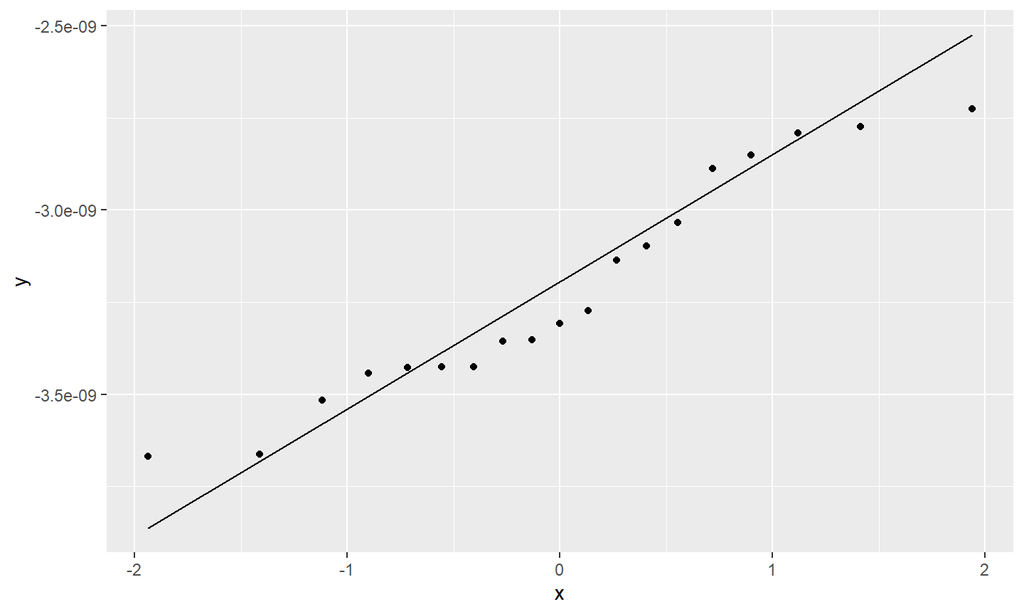

```r
randef <- ranef(usda_mixed)[[1]]

randef %>%
  ggplot(aes(sample=`(Intercept)`))+
  stat_qq()+
  stat_qq_line()
```

```r
#Set up a compact letter display of all pair-wise comparisons
cld(usda_mixed_means,
    adjust = "none",
    Letters = letters,
    reversed = TRUE,
    comparisons = TRUE) -> usda_mixed_cld

# default plot

# ggplot -> necessary steps ?
```

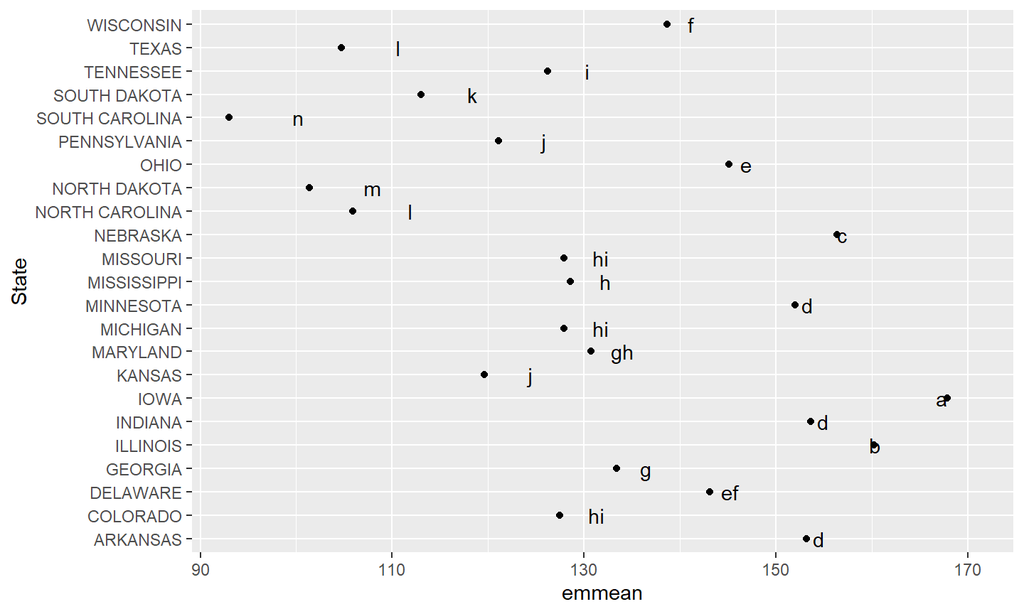

```r
usda_mixed_cld <- usda_mixed_cld %>% as.data.frame()

usda_mixed_cld %>%
  ggplot(aes(emmean, State))+
  geom_point()+
  geom_text(aes(label = .group), nudge_y = 0, nudge_x = 3)
```

```r
usda_mixed_cld$.group <- gsub(" ", "", usda_mixed_cld$.group, fixed = TRUE)

usda_mixed_cld <- usda_mixed_cld %>%
  arrange(emmean) %>%
  rownames_to_column("order") %>%
  mutate(order = as.numeric(order))

usda_mixed_cld <- usda_mixed_cld %>% mutate(State = factor(State, levels = usda_mixed_cld$State[usda_mixed_cld$order]))
# ggplot
```

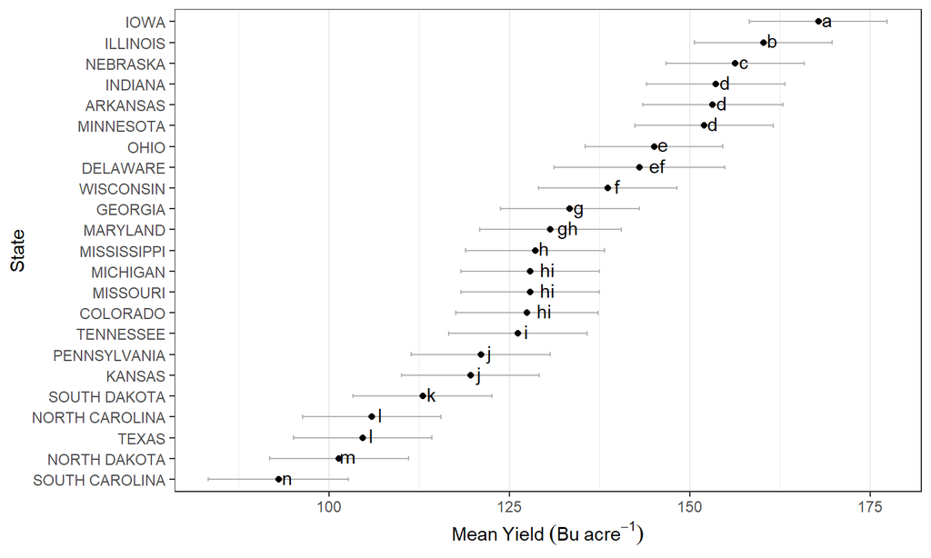

```r
usda_mixed_cld %>%
  ggplot(aes(emmean, State))+
  geom_errorbarh(aes(xmin = asymp.LCL, xmax = asymp.UCL), color = "grey70", height = .2)+
  geom_point()+
  geom_text(aes(label = .group, x = emmean + nchar(.group)*1.2), nudge_y = 0.1)+
  labs(x = expression(Mean~Yield~(Bu~acre^{-1})))+
  theme_bw()+
  theme(panel.grid.major.y = element_blank(),
        panel.grid.minor.y = element_blank()) -> usda_mixed_ggplot; usda_mixed_ggplot
```

## References

- **Model building:** Check out Chapter 10 in *Hobbs, N. T., and Hooten, M. B. (2015). Bayesian models: a statistical primer for ecologists. Princeton University Press.*
- [Dr. Leo Bastos 2019 R workshop](https://www.youtube.com/watch?v=8xyi9By3fM4)